# Swiss Energy Governance Ch.14 - Analyses

Aya Kachi

July 2020

### Libraries

```r
library(ggplot2)
library(likert)
library(foreign)
library(MASS)
library(Hmisc)
library(reshape2)
library(grid)
options(digits=4)
```

### Data - Main dataset

#### Main dataset

- This is the fullest dataset (the ‘main dataset’).
- Two versions (canton and non-canton) have been merged.
- Actor names mentioned in listing items have been cleaned.
- Includes the entire population of ``relevant" stakeholders (N=740), 105 more actors that were involved in the “Wasserzins” process, and 2 more respondents that submitted without out invitation. These 105 actors that were involved only in the Wasserzins case were excluded from our population criteria eventually. They were not invited to the survey either. This is why the dataset contains 847 observations.

```r
data.full <- read.csv("../data/20200625_SESHS_All.csv", sep = ",", header = T, encoding = "UTF-8")
```

#### Data cleaning

- Drop 1 obs whose progress is 0%.
- Keep all those that submitted the survey.
- Drop 2 uninvited submissions. (Pity but I’m following our population identification protocol.)
- Keep obs that are coded as “finished” (completed).

```r
data <- data.full[which(data.full$I_Participation == 1 & data.full$Progress != 0), ]
data <- data[!(data$X == "174" | data$X == "202"), ]
dim1 <- dim(data)
data <- data[which(data$Finished == 1), ]
dim2 <- dim(data)
attach(data)
```

We received 364 submissions, among which 312 completed most parts of the survey. This makes the completion rate 86%. Our analyes will be based on the completed data of N=312.

### Var: Vision on the ES2050 goals

To what extent do Swiss energy stakeholders find these policy goals realistic? We asked the following 8 questions. See **01_BookSwissSH_Fig_VisionOverview.Rmd** for item descriptions.

Original scale: (1) Completely realistic – (4) Completely unrealistic. We’ll reverse the scale, factorize the variables (for ordered logit later), and store it in a new var “varname.f”.

```r
visionlevels <- c('Completely unrealistic', 'Rather unealistic', 'Rather realistic', 'Completely realistic')
vision.list <- c("Q19","Q22","Q25","Q28","Q31_1","Q31_2","Q31_3","Q31_4")
vision.list.f <- c("Q19.f","Q22.f","Q25.f","Q28.f","Q31_1.f","Q31_2.f","Q31_3.f","Q31_4.f")
data[vision.list.f] <- lapply(data[vision.list], function(x) factor((5-x), labels = visionlevels))
detach(data)
attach(data)
```

New: (1) Completely unrealistic, (2) Rather unrealistic, (3) Rather realistic, (4) Completely realistic.

### Var: Fields of activity

Create intuitive dummies that indicate whether an acctor has been active in each field.

```r
## note the original Q56_ are coded 1 or NA. we want it to be 0 or 1.
act.list <- c("Q56_1", "Q56_4", "Q56_5", "Q56_13", "Q56_2")
act.list.new <- c("act.hp", "act.wind", "act.dge", "act.ev", "act.nuc")
data[act.list.new] <- lapply(data[act.list], function(x) ifelse(is.na(x), 0, 1))
detach(data)
attach(data)
```

Among the 312 actors, there are 126 that are active in HP, 89 in wind, 54 in DGE, 119 in EV, and 50 in nuclear.

### Var: Political activeness

We measure political activeness using 7 items. First (in a narrow sense) we use Q35 - whether the org has undertaken (1) definition of a political strategy regarding specific legislation or (2) communication of information and political views to policy makers and/or administration over the last 10 years in the context of Swiss energy policy in general. In adddition, we use Q52 - over the past 10 years whether the org has pursued (3) informal exchange with politicians, (4) accessing non-public parts of the national parliament building (Wandelhalle), (5) participation in hearings of parliamentary commissions, (6) participation in an official working/expert group to draft new legislation, (7) preparation and publication of political opinions and position papers.

```r
## first, make dummies using Q35.
## (1) Both collec and alone. (2) Only alone. (3) Only collec. (4) Not at all. (999) DK.
pol.act.list <- c("Q35_1", "Q35_2")
pol.act.list.new <- c("pol.act1", "pol.act2")
data[pol.act.list.new] <-
  lapply(data[pol.act.list], function(x) ifelse(x==999, NA, ifelse((x==1 | x==2 | x==3), 1, 0)))
## next, make dummies using Q52. change NA to 0.
pol.act.list2 <- c("Q52_1", "Q52_3", "Q52_4", "Q52_5", "Q52_6")
pol.act.list2.new <- c("pol.act3", "pol.act4", "pol.act5", "pol.act6", "pol.act7")
data[pol.act.list2.new] <- lapply(data[pol.act.list2], function(x) ifelse(is.na(x), 0, 1))

## aggregate. simple sum.
data$pol.act <- data$pol.act1 + data$pol.act2 + data$pol.act3 + data$pol.act4 + data$pol.act5 + data$pol.act6 + data$pol.act7
detach(data)
attach(data)

## mean, st dev.
c(summary(pol.act, detail), sd(na.omit(pol.act)))
```

```
##    Min. 1st Qu.  Median    Mean 3rd Qu.    Max.    NA's
##   0.000   3.000   4.000   4.223   6.000   7.000  12.000   1.834
```

### Var: Media activeness

We measure organizations’ media-related activeness using 2 items from Q52 - over the last 10 years whether the org has pursued (1) active involvement in media debates (eg opinion articles or interviews in print media, radio, television, etc.) and (2) communication with the public via digital media (eg Facebook, Instagram, Twitter, etc.).

```r
## make dummies using Q52. change NA to 0.
media.act.list <- c("Q52_8", "Q52_9")
media.act.list.new <- c("media.act1", "media.act2")
data[media.act.list.new] <- lapply(data[media.act.list], function(x) ifelse(is.na(x), 0, 1))

## aggregate. simple sum.
data$media.act = data$media.act1 + data$media.act2
detach(data)
attach(data)
```

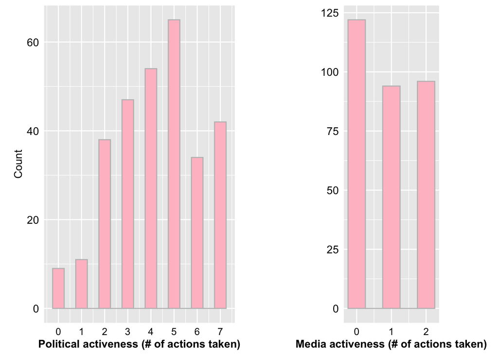

### Var: Level of perceived barriers for **EV**

Using Q29, we’ll measure how much of (i) technical, (ii) stakeholder-related, and (iii) regulatory barrieres the organiation acknowledge in achieving the ES2050 goal for EV. We are interested in assessing whether a certain type of barrier perceptions are systematically related to their feasibility views.

```r
## tech: Tech'l maturity(1) Environmental risks(2) High investment costs(3) Weak infra for EV(6)
## stake: Low accept of EV by cons(4) Info deficits of cons(5) Oppos by int grps(7) Lack support by car dealers(8)
## regulatory: Policy/regulatory risk(9)

data$bartech.ev <- 0
data$bartech.ev[data$Q29_1==1 |data$Q29_2==1 |data$Q29_3==1 | data$Q29_6==1] <- 1
data$barstake.ev <- 0
data$barstake.ev[data$Q29_4==1 |data$Q29_5==1 | data$Q29_7==1 |data$Q29_8==1] <- 1
data$barreg.ev <- 0
data$barreg.ev[data$Q29_9==1] <- 1
detach(data)
attach(data)
```

### Var: Level of perceived barriers for **DGE**

Using Q23, we’ll measure how much of (i) technical, (ii) stakeholder-related, and (iii) regulatory barrieres the organiation acknowledge in achieving the ES2050 goal for DGE.

```r
## tech: High investment costs. (1) High operational costs. (2) Seismic risk. (3) Exploration risk. (4)
## stake: Opposition by citizens (5) Opposition by interest groups. (6)
## regulatory: Policy/regulatory risks. (7)
## OMITTED bc not directly related to DGE tech. The electricity grid is not ready (8)

data$bartech.dge <- 0
data$bartech.dge[data$Q23_1==1 | data$Q23_2==1 | data$Q23_3==1 | data$Q23_4==1] <- 1
data$barstake.dge <- 0
data$barstake.dge[data$Q23_5==1 | data$Q23_6==1 ] <- 1
data$barreg.dge <- 0
data$barreg.dge[data$Q23_7==1] <- 1
detach(data)
attach(data)
```

### Var: Level of perceived barriers for **wind**

Using Q20, we’ll measure how much of (i) technical, (ii) stakeholder-related, and (iii) regulatory barrieres the organiation acknowledge in achieving the ES2050 goal for wind.

```r
## tech: High investment costs. (1) High energy costs. (2) Environmental risks. (3) Technical implementation. (4)
## stake: Opposition by citizens. (5) Opposition by interest groups. (6)
## regulatory: Political/regulatory risks. (7)
## OMITTED bc not directly related to DGE tech. The electricity grid is not ready (8)

data$bartech.wind <- 0
data$bartech.wind[data$Q20_1==1 |data$Q20_2==1 |data$Q20_3==1 | data$Q20_4==1] <- 1
data$barstake.wind <- 0
data$barstake.wind[data$Q29_5==1 | data$Q20_6==1] <- 1
data$barreg.wind <- 0
data$barreg.wind[data$Q20_7==1] <- 1
detach(data)
attach(data)
```

### Var: Level of perceived barriers for **hp**

Using Q32, we’ll measure how much of (i) technical, (ii) stakeholder-related, and (iii) regulatory barrieres the organiation acknowledge in achieving the ES2050 goal for HP.

```r
## tech: High investment costs. (1) High operational costs. (2) High maintenance costs. (3) Environmental risks. (4) Technical implementation. (5)
## stake: Opposition by citizens. (6) Opposition by interest groups. (7)
## regulatory: Policy/regulatory risks. (8) Lacking regulatory coordination. (9)
## OMITTED bc not directly related to DGE tech. The electricity grid is not ready (8)

data$bartech.hp <- 0
data$bartech.hp[data$Q32_1==1 |data$Q32_2==1 |data$Q32_3==1 | data$Q32_4==1 |data$Q32_5==1] <- 1
data$barstake.hp <- 0
data$barstake.hp[data$Q32_6==1 | data$Q32_7==1] <- 1
data$barreg.hp <- 0
data$barreg.hp[data$Q32_8==1 | data$Q32_9==1] <- 1
detach(data)
attach(data)
```

### Explaining vision with ordered logit regressions

Here are my first-cut analyses of Swiss energy stakehodlers’ views on the ES2050 goals in each energy sub-domain. Here, we are mainly interested in assessing whether their feasibility perceptions are correlated with their political and media activeness as well as perceived challenges associated with each technology. I use ordered logit.

For your convenience see also a guide for ordered logit: https://stats.idre.ucla.edu/r/dae/ordinal-logistic-regression/

#### Model specification

Here I’m running 7 regressions, each of which is for one of the seven policy goals. The line “eqn <-…” defines model specification and “model <-…” runs the regression.

```r
goal <- c('ev', 'dge', 'wind', 'hp.mod', 'hp.exp', 'hp.small', 'hp.pump')
goal2 <- c('ev', 'dge', 'wind', 'hp', 'hp', 'hp', 'hp')
depvar <- c('Q28.f', 'Q22.f', 'Q19.f', 'Q31_4.f', 'Q31_3.f', 'Q31_2.f', 'Q31_1.f')
results <- list() ## this is a super amazing placeholder for final results.

for (i in 1:7){
  ## policy goal specific varibles.
  field <- paste0("act.", goal2[i])
  bartech <- paste0("bartech.", goal2[i])
  barstake <- paste0("barstake.", goal2[i])
  barreg <- paste0("barreg.", goal2[i])

  ## define regression eqn.
  common.var <- paste0(" ~ act.nuc + pol.act + media.act ") ## for all goals
  spec.var <- paste0(field, " + ", bartech, " + ", barstake, " + ", barreg)## goal specific vars.
  eqn <- paste0(depvar[i], common.var, " + ", spec.var)

  ## run ordered logit.
  model <- polr(eqn, data = data, Hess = T)
  mod.sum <- summary(model) ## AIC is stored in this
  ## conf int & odd ratios calculations.
  (ctable <- coef(mod.sum))
  p <- pnorm(abs(ctable[, "t value"]), lower.tail = FALSE)*2
  (ctable <- cbind(ctable, "p value" = p)) ## combined table
  (ci <- confint(model, level = 0.95)) ## default method gives profiled CIs
  confint.default(model)
  #exp(coef(model))  ## odds ratios
  ## store odd rations & CI.
  results[[goal[i]]] <- exp(cbind(OR = coef(model), ci))
}
```

#### Regression results - All

Note that when you interpret odds ratios if the confidence interval crosses 1 (e.g. 95%CI 0.9-1.1) this implies there is “no effect”.

```r
results
```

```
## $ev
##                 OR  2.5 % 97.5 %
## act.nuc     0.7536 0.4044 1.4012
## pol.act     0.9794 0.8577 1.1180
## media.act   1.4596 1.0779 1.9837
## act.ev      0.8525 0.5448 1.3321
## bartech.ev  0.4152 0.2395 0.7132
## barstake.ev 0.8175 0.5254 1.2694
## barreg.ev   0.8612 0.3941 1.8782
##
## $dge
##                  OR  2.5 % 97.5 %
## act.nuc      0.9508 0.4992 1.8065
## pol.act      1.0405 0.9096 1.1904
## media.act    1.3613 1.0045 1.8494
## act.dge      1.0248 0.5568 1.8778
## bartech.dge  0.3262 0.1470 0.7161
## barstake.dge 1.0458 0.6631 1.6518
## barreg.dge   1.2701 0.7443 2.1667
##
## $wind
##                   OR  2.5 % 97.5 %
## act.nuc       1.2422 0.6484 2.3707
## pol.act       0.9164 0.8020 1.0460
## media.act     1.4973 1.1128 2.0210
## act.wind      0.5941 0.3544 0.9893
## bartech.wind  0.4204 0.2644 0.6634
## barstake.wind 1.1376 0.6342 2.0508
## barreg.wind   0.8706 0.5345 1.4153
##
## $hp.mod
##                 OR  2.5 % 97.5 %
## act.nuc     1.2067 0.6349  2.340
## pol.act     1.0125 0.8821  1.162
## media.act   0.9295 0.6825  1.266
## act.hp      0.9213 0.5726  1.486
## bartech.hp  2.0423 1.1729  3.553
## barstake.hp 2.1337 1.2654  3.599
## barreg.hp   0.8169 0.5149  1.299
##
```

[output cut: 14 more lines]

```
## media.act   1.1871 0.8825  1.599
## act.hp      0.6394 0.4010  1.016
## bartech.hp  1.7738 1.0268  3.074
## barstake.hp 1.4049 0.8382  2.357
## barreg.hp   0.9309 0.5903  1.469
##
## $hp.pump
##                 OR  2.5 % 97.5 %
## act.nuc     0.6217 0.3253  1.180
## pol.act     0.9915 0.8658  1.135
## media.act   1.2406 0.9179  1.680
## act.hp      0.9741 0.6058  1.566
## bartech.hp  0.8280 0.4742  1.445
## barstake.hp 1.3396 0.7881  2.290
## barreg.hp   1.2117 0.7684  1.914
```

### Political activeness by fields of activity

What is the mean political activeness level of the actors that are active in HP, wind, etc., respectively?

```r
lapply(data[act.list.new], function(x) summary(pol.act[x==1]))
```

```
## $act.hp
##    Min. 1st Qu.  Median    Mean 3rd Qu.    Max.    NA's
##    0.00    4.00    5.00    4.64    6.00    7.00       3
##
## $act.wind
##    Min. 1st Qu.  Median    Mean 3rd Qu.    Max.    NA's
##    0.00    3.00    5.00    4.47    6.00    7.00       2
##
## $act.dge
##    Min. 1st Qu.  Median    Mean 3rd Qu.    Max.    NA's
##    1.00    4.00    5.00    4.74    6.00    7.00       1
##
## $act.ev
##    Min. 1st Qu.  Median    Mean 3rd Qu.    Max.    NA's
##    1.00    3.00    5.00    4.64    6.00    7.00       2
##
## $act.nuc
##    Min. 1st Qu.  Median    Mean 3rd Qu.    Max.
##    1.00    4.00    5.00    4.92    6.00    7.00
```

### Media activeness by fields of activity

Similarly for the mean media-related activeness?

```r
lapply(data[act.list.new], function(x) summary(media.act[x==1]))
```

```
## $act.hp
##    Min. 1st Qu.  Median    Mean 3rd Qu.    Max.
##    0.00    0.00    1.00    1.05    2.00    2.00
##
## $act.wind
##    Min. 1st Qu.  Median    Mean 3rd Qu.    Max.
##    0.00    0.00    1.00    1.04    2.00    2.00
##
## $act.dge
##    Min. 1st Qu.  Median    Mean 3rd Qu.    Max.
##   0.000   0.000   1.000   0.963   2.000   2.000
##
## $act.ev
##    Min. 1st Qu.  Median    Mean 3rd Qu.    Max.
##     0.0     0.0     1.0     1.1     2.0     2.0
##
## $act.nuc
##    Min. 1st Qu.  Median    Mean 3rd Qu.    Max.
##    0.00    1.00    2.00    1.36    2.00    2.00
```

### Variables (considered but) not included in the regressions

#### Var: self-stated influence

I don’t remember why I needed a factor variable… probably for graphing.

```r
infl.sub.levels <- c('No influence at all', 'Very little influence', 'Little influence', 'Moderate influence', 'Strong influence', 'Very strong influence')
data$infl.sub <- data$Q16
data$infl.sub.f <- factor(data$Q16, labels = infl.sub.levels)
```

#### Var: Funding political advertisement

The item asks whether the organisation pursued the following activities during the last ten years - (11) funding of pol advertisement.

```r
data$fund.ad <- ifelse(is.na(data$Q52_11), 0, 1)
```

#### Var: Funding research

The item asks whether the organisation pursued the following activities during the last ten years - (7) financing or conducting reserach.

```r
data$fund.ad <- ifelse(is.na(data$Q52_7), 0, 1)
detach(data)
attach(data)
```